# Price's Law applied to Movie Revenues

This will be an investigation as to wheether Price's law apllies to a single year (2015 and 2010) and to the total number of movies over all the years provided.

```python
import pandas as pd
import numpy as np
import matplotlib.pyplot as plt

movie_data = pd.read_csv('tmdb-movies.csv')
```

```python
np.sqrt(len(movie_data))
```

```
104.2401074443038
```

```python
Total_revenue = movie_data['revenue'].sum()

Total_revenue_adj = movie_data['revenue_adj'].sum
```

Since it appears that revenue figures are not available for all titles. We'll start by removing the titles without data and then sorting the values in descending order.

```python
sorted_revenue = movie_data.sort_values('revenue_adj', ascending=False, )
```

```python
len(sorted_revenue)
```

```
10866
```

```python
sorted_revenue
```

|  | id | imdb_id | popularity | budget | revenue | original_title | cast | homepage | director | tagline | ... | overview | runtime | genres | production_companies | release_date | vote_count | vote_average | release_year | budget_adj | revenue_adj |
| --- | --- | --- | --- | --- | --- | --- | --- | --- | --- | --- | --- | --- | --- | --- | --- | --- | --- | --- | --- | --- | --- |
| 1386 | 19995 | tt0499549 | 9.432768 | 237000000 | 2781505847 | Avatar | Sam Worthington\|Zoe Saldana\|Sigourney Weaver\|S... | http://www.avatarmovie.com/ | James Cameron | Enter the World of Pandora. | ... | In the 22nd century, a paraplegic Marine is di... | 162 | Action\|Adventure\|Fantasy\|Science Fiction | Ingenious Film Partners\|Twentieth Century Fox ... | 12/10/09 | 8458 | 7.1 | 2009 | 2.408869e+08 | 2.827124e+09 |
| 1329 | 11 | tt0076759 | 12.037933 | 11000000 | 775398007 | Star Wars | Mark Hamill\|Harrison Ford\|Carrie Fisher\|Peter ... | http://www.starwars.com/films/star-wars-episod... | George Lucas | A long time ago in a galaxy far, far away... | ... | Princess Leia is captured and held hostage by ... | 121 | Adventure\|Action\|Science Fiction | Lucasfilm\|Twentieth Century Fox Film Corporation | 3/20/77 | 4428 | 7.9 | 1977 | 3.957559e+07 | 2.789712e+09 |
| 5231 | 597 | tt0120338 | 4.355219 | 200000000 | 1845034188 | Titanic | Kate Winslet\|Leonardo DiCaprio\|Frances Fisher\|... | http://www.titanicmovie.com/menu.html | James Cameron | Nothing on Earth could come between them. | ... | 84 years later, a 101-year-old woman named Ros... | 194 | Drama\|Romance\|Thriller | Paramount Pictures\|Twentieth Century Fox Film ... | 11/18/97 | 4654 | 7.3 | 1997 | 2.716921e+08 | 2.506406e+09 |
| 10594 | 9552 | tt0070047 | 2.010733 | 8000000 | 441306145 | The Exorcist | Linda Blair\|Max von Sydow\|Ellen Burstyn\|Jason ... | http://theexorcist.warnerbros.com/ | William Friedkin | Something almost beyond comprehension is happe... | ... | 12-year-old Regan MacNeil begins to adapt an e... | 122 | Drama\|Horror\|Thriller | Warner Bros.\|Hoya Productions | 12/26/73 | 1113 | 7.2 | 1973 | 3.928928e+07 | 2.167325e+09 |
| 9806 | 578 | tt0073195 | 2.563191 | 7000000 | 470654000 | Jaws | Roy Scheider\|Robert Shaw\|Richard Dreyfuss\|Lorr... | http://www.jaws25.com/ | Steven Spielberg | Don't go in the water. | ... | An insatiable great white shark terrorizes the... | 124 | Horror\|Thriller\|Adventure | Universal Pictures\|Zanuck/Brown Productions | 6/18/75 | 1415 | 7.3 | 1975 | 2.836275e+07 | 1.907006e+09 |
| 3 | 140607 | tt2488496 | 11.173104 | 200000000 | 2068178225 | Star Wars: The Force Awakens | Harrison Ford\|Mark Hamill\|Carrie Fisher\|Adam D... | http://www.starwars.com/films/star-wars-episod... | J.J. Abrams | Every generation has a story. | ... | Thirty years after defeating the Galactic Empi... | 136 | Action\|Adventure\|Science Fiction\|Fantasy | Lucasfilm\|Truenorth Productions\|Bad Robot | 12/15/15 | 5292 | 7.5 | 2015 | 1.839999e+08 | 1.902723e+09 |
| 8889 | 601 | tt0083866 | 2.900556 | 10500000 | 792910554 | E.T. the Extra-Terrestrial | Henry Thomas\|Drew Barrymore\|Robert MacNaughton... | http://www.et20.com/ | Steven Spielberg | He is afraid. He is alone. He is three million... | ... | A science fiction fairytale about an extra-ter... | 115 | Science Fiction\|Adventure\|Family\|Fantasy | Universal Pictures\|Amblin Entertainment | 4/3/82 | 1830 | 7.2 | 1982 | 2.372625e+07 | 1.791694e+09 |
| 8094 | 1642 | tt0113957 | 1.136610 | 22000000 | 1106279658 | The Net | Sandra Bullock\|Jeremy Northam\|Dennis Miller\|We... | NaN | Irwin Winkler | Her driver's license. Her credit cards. Her ba... | ... | Angela Bennett is a freelance software enginee... | 114 | Crime\|Drama\|Mystery\|Thriller\|Action | Columbia Pictures | 7/28/95 | 201 | 5.6 | 1995 | 3.148127e+07 | 1.583050e+09 |
| 10110 | 12230 | tt0055254 | 2.631987 | 4000000 | 215880014 | One Hundred and One Dalmatians | Rod Taylor\|J. Pat O'Malley\|Betty Lou Gerson\|Ma... | NaN | Clyde Geronimi\|Hamilton Luske\|Wolfgang Reitherman | The Canine Caper of the Century | ... | When a litter of dalmatian puppies are abducte... | 79 | Adventure\|Animation\|Comedy\|Family | Walt Disney Productions | 1/25/61 | 913 | 6.6 | 1961 | 2.917944e+07 | 1.574815e+09 |
| 4361 | 24428 | tt0848228 | 7.637767 | 220000000 | 1519557910 | The Avengers | Robert Downey Jr.\|Chris Evans\|Mark Ruffalo\|Chr... | http://marvel.com/avengers_movie/ | Joss Whedon | Some assembly required. | ... | When an unexpected enemy emerges and threatens... | 143 | Science Fiction\|Action\|Adventure | Marvel Studios | 4/25/12 | 8903 | 7.3 | 2012 | 2.089437e+08 | 1.443191e+09 |
| 7309 | 1891 | tt0080684 | 5.488441 | 18000000 | 538400000 | The Empire Strikes Back | Mark Hamill\|Harrison Ford\|Carrie Fisher\|Billy ... | http://www.starwars.com/films/star-wars-episod... | Irvin Kershner | The Adventure Continues... | ... | The epic saga continues as Luke Skywalker, in ... | 124 | Adventure\|Action\|Science Fiction | Lucasfilm\|Twentieth Century Fox Film Corporation | 1/1/80 | 3954 | 8.0 | 1980 | 4.762866e+07 | 1.424626e+09 |
| 0 | 135397 | tt0369610 | 32.985763 | 150000000 | 1513528810 | Jurassic World | Chris Pratt\|Bryce Dallas Howard\|Irrfan Khan\|Vi... | http://www.jurassicworld.com/ | Colin Trevorrow | The park is open. | ... | Twenty-two years after the events of Jurassic ... | 124 | Action\|Adventure\|Science Fiction\|Thriller | Universal Studios\|Amblin Entertainment\|Legenda... | 6/9/15 | 5562 | 6.5 | 2015 | 1.379999e+08 | 1.392446e+09 |
| 10223 | 329 | tt0107290 | 2.204926 | 63000000 | 920100000 | Jurassic Park | Sam Neill\|Laura Dern\|Jeff Goldblum\|Richard Att... | http://www.jurassicpark.com/ | Steven Spielberg | An adventure 65 million years in the making. | ... | A wealthy entrepreneur secretly creates a them... | 127 | Adventure\|Science Fiction | Universal Pictures\|Amblin Entertainment | 6/11/93 | 3169 | 7.4 | 1993 | 9.509661e+07 | 1.388863e+09 |
| 4 | 168259 | tt2820852 | 9.335014 | 190000000 | 1506249360 | Furious 7 | Vin Diesel\|Paul Walker\|Jason Statham\|Michelle ... | http://www.furious7.com/ | James Wan | Vengeance Hits Home | ... | Deckard Shaw seeks revenge against Dominic Tor... | 137 | Action\|Crime\|Thriller | Universal Pictures\|Original Film\|Media Rights ... | 4/1/15 | 2947 | 7.3 | 2015 | 1.747999e+08 | 1.385749e+09 |
| 10398 | 9325 | tt0061852 | 2.550704 | 4000000 | 205843612 | The Jungle Book | Phil Harris\|Sebastian Cabot\|Louis Prima\|George... | NaN | Wolfgang Reitherman | The Jungle is JUMPIN'! | ... | The Jungle Book follows the ups and downs of t... | 78 | Family\|Animation\|Adventure | Walt Disney Pictures | 10/18/67 | 928 | 7.0 | 1967 | 2.614705e+07 | 1.345551e+09 |
| 4949 | 122 | tt0167260 | 7.122455 | 94000000 | 1118888979 | The Lord of the Rings: The Return of the King | Elijah Wood\|Ian McKellen\|Viggo Mortensen\|Liv T... | http://www.lordoftherings.net | Peter Jackson | The eye of the enemy is moving. | ... | Aragorn is revealed as the heir to the ancient... | 201 | Adventure\|Fantasy\|Action | WingNut Films\|New Line Cinema | 12/1/03 | 5636 | 7.9 | 2003 | 1.114231e+08 | 1.326278e+09 |
| 14 | 99861 | tt2395427 | 5.944927 | 280000000 | 1405035767 | Avengers: Age of Ultron | Robert Downey Jr.\|Chris Hemsworth\|Mark Ruffalo... | http://marvel.com/movies/movie/193/avengers_ag... | Joss Whedon | A New Age Has Come. | ... | When Tony Stark tries to jumpstart a dormant p... | 141 | Action\|Adventure\|Science Fiction | Marvel Studios\|Prime Focus\|Revolution Sun Studios | 4/22/15 | 4304 | 7.4 | 2015 | 2.575999e+08 | 1.292632e+09 |
| 3374 | 12445 | tt1201607 | 5.711315 | 125000000 | 1327817822 | Harry Potter and the Deathly Hallows: Part 2 | Daniel Radcliffe\|Rupert Grint\|Emma Watson\|Alan... | http://www.harrypotter.com | David Yates | It all ends here. | ... | Harry, Ron and Hermione continue their quest t... | 130 | Adventure\|Family\|Fantasy | Warner Bros.\|Heyday Films\|Moving Picture Compa... | 7/7/11 | 3750 | 7.7 | 2011 | 1.211748e+08 | 1.287184e+09 |
| 7269 | 238 | tt0068646 | 5.738034 | 6000000 | 245066411 | The Godfather | Marlon Brando\|Al Pacino\|James Caan\|Richard S. ... | http://www.thegodfather.com/ | Francis Ford Coppola | An offer you can't refuse. | ... | Spanning the years 1945 to 1955, a chronicle o... | 175 | Drama\|Crime | Paramount Pictures\|Alfran Productions | 3/15/72 | 3970 | 8.3 | 1972 | 3.128737e+07 | 1.277914e+09 |
| 7987 | 1892 | tt0086190 | 4.828854 | 32350000 | 572700000 | Return of the Jedi | Mark Hamill\|Harrison Ford\|Carrie Fisher\|Billy ... | http://www.starwars.com/films/star-wars-episod... | Richard Marquand | The Empire Falls... | ... | As Rebel leaders map their strategy for an all... | 135 | Adventure\|Action\|Science Fiction | Lucasfilm\|Twentieth Century Fox Film Corporation | 5/23/83 | 3101 | 7.8 | 1983 | 7.082424e+07 | 1.253819e+09 |
| 2412 | 1893 | tt0120915 | 3.526029 | 115000000 | 924317558 | Star Wars: Episode I - The Phantom Menace | Liam Neeson\|Ewan McGregor\|Natalie Portman\|Jake... | http://www.starwars.com/films/star-wars-episod... | George Lucas | Every generation has a legend. Every journey h... | ... | Anakin Skywalker, a young slave strong with th... | 136 | Adventure\|Action\|Science Fiction | Lucasfilm | 5/19/99 | 2823 | 6.3 | 1999 | 1.505411e+08 | 1.209981e+09 |
| 2634 | 671 | tt0241527 | 8.021423 | 125000000 | 976475550 | Harry Potter and the Philosopher's Stone | Daniel Radcliffe\|Rupert Grint\|Emma Watson\|John... | http://harrypotter.warnerbros.com/harrypottera... | Chris Columbus | Let the Magic Begin. | ... | Harry Potter has lived under the stairs at his... | 152 | Adventure\|Fantasy\|Family | 1492 Pictures\|Warner Bros.\|Heyday Films | 11/16/01 | 4265 | 7.2 | 2001 | 1.539360e+08 | 1.202518e+09 |
| 5422 | 109445 | tt2294629 | 6.112766 | 150000000 | 1274219009 | Frozen | Kristen Bell\|Idina Menzel\|Jonathan Groff\|Josh ... | http://movies.disney.com/frozen | Chris Buck\|Jennifer Lee | Only the act of true love will thaw a frozen h... | ... | Young princess Anna of Arendelle dreams about ... | 102 | Animation\|Adventure\|Family | Walt Disney Pictures\|Walt Disney Animation Stu... | 11/27/13 | 3369 | 7.5 | 2013 | 1.404050e+08 | 1.192711e+09 |
| 4180 | 8587 | tt0110357 | 4.782688 | 45000000 | 788241776 | The Lion King | Jonathan Taylor Thomas\|Matthew Broderick\|James... | http://movies.disney.com/the-lion-king | Roger Allers\|Rob Minkoff | Life's greatest adventure is finding your plac... | ... | A young lion cub named Simba can't wait to be ... | 89 | Family\|Animation\|Drama | Walt Disney Pictures\|Walt Disney Feature Anima... | 6/23/94 | 3489 | 7.7 | 1994 | 6.620002e+07 | 1.159592e+09 |
| 6555 | 58 | tt0383574 | 4.205992 | 200000000 | 1065659812 | Pirates of the Caribbean: Dead Man's Chest | Johnny Depp\|Orlando Bloom\|Keira Knightley\|Bill... | http://disney.go.com/disneypictures/pirates/ | Gore Verbinski | Jack is back! | ... | The high-seas adventures of happy-go-lucky tro... | 151 | Adventure\|Fantasy\|Action | Walt Disney Pictures\|Jerry Bruckheimer Films\|S... | 6/20/06 | 3181 | 6.8 | 2006 | 2.163338e+08 | 1.152691e+09 |
| 5425 | 68721 | tt1300854 | 4.946136 | 200000000 | 1215439994 | Iron Man 3 | Robert Downey Jr.\|Gwyneth Paltrow\|Guy Pearce\|D... | http://marvel.com/ironman3 | Shane Black | Unleash the power behind the armor. | ... | When Tony Stark's world is torn apart by a for... | 130 | Action\|Adventure\|Science Fiction | Marvel Studios | 4/18/13 | 6882 | 6.9 | 2013 | 1.872067e+08 | 1.137692e+09 |
| 8457 | 602 | tt0116629 | 4.480733 | 75000000 | 816969268 | Independence Day | Will Smith\|Bill Pullman\|Jeff Goldblum\|Mary McD... | NaN | Roland Emmerich | Earth. Take a good look. It might be your last. | ... | On July 2, a giant alien mothership enters orb... | 145 | Action\|Adventure\|Science Fiction | Twentieth Century Fox Film Corporation\|Centrop... | 6/25/96 | 2000 | 6.6 | 1996 | 1.042663e+08 | 1.135764e+09 |
| 10690 | 15121 | tt0059742 | 1.313676 | 8200000 | 163214286 | The Sound of Music | Julie Andrews\|Christopher Plummer\|Eleanor Park... | NaN | Robert Wise | The happiest sound in all the world! | ... | Film adaptation of a classic Rodgers and Hamme... | 174 | Drama\|Family\|Music\|Romance | Robert Wise Productions\|Argyle Enterprises | 3/2/65 | 620 | 7.2 | 1965 | 5.674862e+07 | 1.129535e+09 |
| 3911 | 121 | tt0167261 | 8.095275 | 79000000 | 926287400 | The Lord of the Rings: The Two Towers | Elijah Wood\|Ian McKellen\|Viggo Mortensen\|Liv T... | http://www.lordoftherings.net/ | Peter Jackson | A New Power Is Rising. | ... | Frodo and Sam are trekking to Mordor to destro... | 179 | Adventure\|Fantasy\|Action | WingNut Films\|New Line Cinema\|The Saul Zaentz ... | 12/18/02 | 5114 | 7.8 | 2002 | 9.576865e+07 | 1.122902e+09 |
| 1334 | 840 | tt0075860 | 1.104816 | 20000000 | 303788635 | Close Encounters of the Third Kind | Richard Dreyfuss\|François Truffaut\|Teri Garr\|... | NaN | Steven Spielberg | We are not alone. | ... | After an encounter with UFOs, a line worker fe... | 135 | Science Fiction\|Drama | Columbia Pictures Corporation\|EMI Films\|Julia ... | 11/16/77 | 600 | 7.0 | 1977 | 7.195562e+07 | 1.092965e+09 |
| ... | ... | ... | ... | ... | ... | ... | ... | ... | ... | ... | ... | ... | ... | ... | ... | ... | ... | ... | ... | ... | ... |
| 5719 | 222461 | tt2229511 | 0.373514 | 0 | 0 | Wer | A.J. Cook\|Sebastian Roché\|Vik Sahay\|Stephanie... | NaN | William Brent Bell | NaN | ... | A defense attorney begins to suspect that her ... | 89 | Horror\|Mystery\|Thriller | Room 101\|Incentive Filmed Entertainment\|FilmDi... | 11/16/13 | 44 | 5.4 | 2013 | 0.000000e+00 | 0.000000e+00 |
| 5718 | 239471 | tt2707792 | 0.374148 | 0 | 0 | Bonnie & Clyde | Holliday Grainger\|Emile Hirsch\|Dale Dickey\|Lan... | NaN | Bruce Beresford | NaN | ... | Bonnie and Clyde is a two-part film about two ... | 174 | Crime\|Drama | NaN | 12/8/13 | 38 | 6.9 | 2013 | 0.000000e+00 | 0.000000e+00 |
| 5753 | 150202 | tt1457765 | 0.536513 | 0 | 0 | The Haunting in Connecticut 2: Ghosts of Georgia | Chad Michael Murray\|Katee Sackhoff\|Abigail Spe... | NaN | Tom Elkins | NaN | ... | Sequel to the 2009 mezzo-mezzo supernatural ho... | 101 | Horror\|Drama\|Thriller | Gold Circle Films | 2/1/13 | 108 | 5.6 | 2013 | 0.000000e+00 | 0.000000e+00 |
| 5755 | 198287 | tt1928340 | 0.328471 | 0 | 0 | The Philosophers | James D'Arcy\|Sophie Lowe\|Freddie Stroma\|Rhys W... | http://www.anolivebranchmedia.com/philosophers... | John Huddles | NaN | ... | At an international school in Jakarta, a philo... | 100 | Drama\|Fantasy\|Science Fiction\|Thriller | An Olive Branch Productions\|SCTV | 7/6/13 | 173 | 6.3 | 2013 | 0.000000e+00 | 0.000000e+00 |
| 5791 | 183258 | tt2095568 | 0.293332 | 6000000 | 0 | All Things To All Men | Toby Stephens\|Rufus Sewell\|Gabriel Byrne\|Leo G... | NaN | George Isaac | Once You Are In. There's No Getting Out | ... | A thief is caught up in a deadly game of cat-a... | 84 | Thriller\|Crime | Universal Pictures | 4/5/13 | 12 | 4.4 | 2013 | 5.616200e+06 | 0.000000e+00 |
| 5757 | 196254 | tt2946582 | 0.328083 | 0 | 0 | Barbie: Mariposa and The Fairy Princess | Kelly Sheridan\|Maryke Hendrikse\|Tabitha St. Ge... | http://www.barbie.com | William Lau | Friendship overcomes any obstacle. | ... | Mariposa and her furry friend Zee returns in B... | 75 | Fantasy\|Animation\|Family | Universal Studios | 8/26/13 | 21 | 6.3 | 2013 | 0.000000e+00 | 0.000000e+00 |
| 5790 | 172847 | tt2012011 | 0.293833 | 0 | 0 | Scenic Route | Josh Duhamel\|Dan Fogler\|Miracle Laurie\|Christi... | NaN | Kevin Goetz\|Michael Goetz | There is no turning back | ... | Stranded on an isolated desert road, two life-... | 85 | Drama\|Thriller | Anonymous Content\|Best Medicine Productions | 8/23/13 | 49 | 6.1 | 2013 | 0.000000e+00 | 0.000000e+00 |
| 5788 | 195757 | tt1778924 | 0.295323 | 0 | 0 | The Ultimate Life | Peter Fonda\|Bill Cobbs\|Ali Hillis\|Lee Meriweth... | http://www.theultimatelifemovie.com/ | Michael Landon, Jr. | Some things are worth more than money. | ... | Despite his best intentions, billionaire Jason... | 105 | Drama\|Romance | NaN | 9/6/13 | 12 | 6.8 | 2013 | 0.000000e+00 | 0.000000e+00 |
| 5786 | 206213 | tt2446502 | 0.296488 | 0 | 0 | Zombie Hunter | Martin Copping\|Danny Trejo\|Clare Niederpruem\|T... | https://www.facebook.com/zombiehuntermovie | Kevin King | NaN | ... | Zombie Hunter is set in a post-apocalyptic Zom... | 93 | Comedy\|Action\|Science Fiction\|Thriller | Arrowstorm Entertainment\|The Klimax | 7/25/13 | 23 | 3.5 | 2013 | 0.000000e+00 | 0.000000e+00 |
| 5784 | 140222 | tt1976989 | 0.299109 | 0 | 0 | Love and Honor | Liam Hemsworth\|Teresa Palmer\|Aimee Teegarden\|C... | NaN | Danny Mooney | NaN | ... | When a young soldier in Vietnam gets dumped by... | 92 | Drama\|Romance\|War | Deep Blue Pictures\|Red 56 | 3/22/13 | 75 | 6.1 | 2013 | 0.000000e+00 | 0.000000e+00 |
| 5783 | 165739 | tt1551630 | 0.299117 | 83000000 | 0 | Pawn | Forest Whitaker\|Nikki Reed\|Sean Faris\|Ray Liot... | NaN | David A. Armstrong | Every move is a game changer | ... | A petty robbery spirals into a tense hostage s... | 88 | Crime\|Thriller | Imprint Entertainment\|Most Films\|Extravaganza ... | 4/23/13 | 37 | 5.5 | 2013 | 7.769077e+07 | 0.000000e+00 |
| 5782 | 199578 | tt2147459 | 0.301709 | 0 | 0 | Patrick | Rachel Griffiths\|Charles Dance\|Jackson Gallagh... | NaN | Mark Hartley | Cruel. Controlling. Comatose. | ... | Patrick lays comatose in a small private hospi... | 96 | Horror\|Science Fiction\|Thriller | Screen Australia\|F.G. Film Productions | 10/15/13 | 26 | 4.2 | 2013 | 0.000000e+00 | 0.000000e+00 |
| 5781 | 100544 | tt1925479 | 0.346557 | 12000000 | 0 | Officer Down | Stephen Lang\|David Boreanaz\|Dominic Purcell\|An... | NaN | Brian A Miller | Once a bad cop, always a bad cop. | ... | When a cop's crooked past comes back to get hi... | 98 | Crime\|Drama | Jeff Most Productions | 1/22/13 | 18 | 5.3 | 2013 | 1.123240e+07 | 0.000000e+00 |
| 5780 | 168399 | tt2369205 | 0.303536 | 7500000 | 0 | Pionér | Wes Bentley\|Stephen Lang\|Aksel Hennie\|Jonathan... | http://www.pioneerthefilm.com/ | Erik Skjoldbjærg | NaN | ... | Pioneer is set in the early '80s, at the begin... | 106 | Thriller | Pandora Filmproduktion\|Matila Röhr Production... | 8/30/13 | 20 | 5.3 | 2013 | 7.020250e+06 | 0.000000e+00 |
| 5779 | 157351 | tt1838520 | 0.304099 | 0 | 0 | The Truth About Emanuel | Kaya Scodelario\|Jessica Biel\|Alfred Molina\|Fra... | http://emanuelandthetruthaboutfishes.com/ | Francesca Gregorini | Two Lives. Two Voids. One Secret. | ... | A troubled young woman becomes obsessed with h... | 96 | Drama\|Thriller | MRB Productions\|Rooks Nest Entertainment\|Pisce... | 4/26/13 | 41 | 6.2 | 2013 | 0.000000e+00 | 0.000000e+00 |
| 5776 | 122369 | tt2082152 | 0.306125 | 0 | 0 | 13 Eerie | Katharine Isabelle\|Brendan Fehr\|Brendan Fletch... | NaN | Lowell Dean | We prey for you | ... | Six ambitious forensic undergrads are pitted a... | 87 | Horror\|Thriller | Don Carmody Productions\|Minds Eye Entertainment | 4/2/13 | 15 | 4.0 | 2013 | 0.000000e+00 | 0.000000e+00 |
| 5773 | 205939 | tt1913178 | 0.312296 | 0 | 0 | The Crown and the Dragon | Nicola Posener\|Vidal Sancho\|David Haydn\|Amy De... | https://www.facebook.com/TheCrownandtheDragon?... | Anne K. Black | NaN | ... | In a war-torn country that is plagued by a vic... | 91 | Fantasy\|Adventure | Arrowstorm Entertainment | 7/25/13 | 12 | 5.5 | 2013 | 0.000000e+00 | 0.000000e+00 |
| 5771 | 187462 | tt1037222 | 0.313089 | 0 | 0 | Robosapien: Rebooted | Kim Coates\|Penelope Ann Miller\|Joaquim de Alme... | NaN | Sean McNamara | NaN | ... | At Kinetech Labs, an inventor named Allan Toph... | 86 | Adventure\|Drama\|Family\|Science Fiction | NaN | 4/1/13 | 16 | 5.3 | 2013 | 0.000000e+00 | 0.000000e+00 |
| 5768 | 197033 | tt2235902 | 0.314497 | 0 | 0 | Geography Club | Scott Bakula\|Cameron Deane Stewart\|Justin Deel... | http://geographyclub.com/ | Gary Entin | They formed a club they thought nobody would j... | ... | At Goodkind High School, a group of students o... | 79 | Comedy\|Drama\|Romance | Huffington Pictures\|Levy Leder Company | 5/22/13 | 33 | 6.4 | 2013 | 0.000000e+00 | 0.000000e+00 |
| 5767 | 217896 | tt2569236 | 0.315607 | 0 | 0 | Suddenly | Dominic Purcell\|Ray Liotta\|Erin Karpluk\|Steve ... | NaN | Uwe Boll | NaN | ... | Four assassins led by Baron, pose as Secret Se... | 90 | Thriller | Canadian Film or Video Production Tax Credit (... | 8/8/13 | 12 | 3.3 | 2013 | 0.000000e+00 | 0.000000e+00 |
| 5766 | 158914 | tt1951216 | 0.317114 | 0 | 0 | The Look of Love | Steve Coogan\|Anna Friel\|Imogen Poots\|Tamsin Eg... | NaN | Michael Winterbottom | Based on the outrageously true story of Britai... | ... | Paul Raymond builds a porn, entertainment and ... | 105 | Comedy\|Drama | Revolution Films\|Film Four International\|Lipsy... | 4/26/13 | 23 | 5.0 | 2013 | 0.000000e+00 | 0.000000e+00 |
| 5765 | 139997 | tt1972819 | 0.318589 | 0 | 0 | And While We Were Here | Kate Bosworth\|Claire Bloom\|Iddo Goldberg\|Jamie... | NaN | Kat Coiro | A forbidden memory... | ... | Trapped in a loveless marriage, a troubled wri... | 83 | Drama | NaN | 9/13/13 | 18 | 5.7 | 2013 | 0.000000e+00 | 0.000000e+00 |
| 5764 | 169219 | tt1905040 | 0.319972 | 0 | 0 | The Dyatlov Pass Incident | Gemma Atkinson\|Richard Reid\|Matt Stokoe\|Holly ... | NaN | Renny Harlin | History always repeats itself. | ... | Five young filmmakers retrace the steps of a d... | 100 | Thriller\|Mystery | Non-Stop Productions\|Future Films\|Aldamisa Ent... | 2/27/13 | 77 | 5.3 | 2013 | 0.000000e+00 | 0.000000e+00 |
| 5763 | 174326 | tt1582465 | 0.321236 | 0 | 0 | A Birder's Guide to Everything | Kodi Smit-McPhee\|James Le Gros\|Ben Kingsley\|Al... | http://www.abirdersguidetoeverything.com/ | Rob Meyer | Find your reason to fly. | ... | David Portnoy, a 15-year-old birding fanatic, ... | 86 | Comedy | dreamFly Productions\|Escape Pictures\|Lavender ... | 4/21/13 | 14 | 6.5 | 2013 | 0.000000e+00 | 0.000000e+00 |
| 5762 | 189680 | tt2186766 | 0.321464 | 0 | 0 | All Stars | Ashley Jensen\|Kimberley Walsh\|Ashley Walters\|K... | NaN | Ben Gregor | 6 misfits. One show...No way! | ... | Two kids look to throw an ambitious dance show... | 106 | Comedy\|Family | Vertigo Films | 5/1/13 | 10 | 5.5 | 2013 | 0.000000e+00 | 0.000000e+00 |
| 5761 | 255718 | tt3504064 | 0.322876 | 0 | 0 | Barbie: The Pearl Princess | Katie Crown\|Brian Doe\|Patrick Gilmore\|Simon Hi... | NaN | Terry Klassen | NaN | ... | Barbie plays Lumina, a mermaid girl with the p... | 73 | Family\|Animation | Universal Pictures Corporation | 2/19/13 | 23 | 6.2 | 2013 | 0.000000e+00 | 0.000000e+00 |
| 5760 | 57210 | tt1833888 | 0.326279 | 0 | 0 | Angels Sing | Chandler Canterbury\|Willie Nelson\|Harry Connic... | http://www.whenangelssingmovie.com/ | Tim McCanlies | Christmas comes but once a year, but the memor... | ... | As a child, Michael Walker wished every day co... | 87 | TV Movie\|Family\|Drama | When Angels Sing | 10/19/13 | 12 | 5.4 | 2013 | 0.000000e+00 | 0.000000e+00 |
| 5759 | 159092 | tt2318527 | 0.326562 | 2500000 | 0 | Hell Baby | Rob Corddry\|Leslie Bibb\|Keegan-Michael Key\|Pau... | NaN | Ben Garant\|Thomas Lennon | The Devil got a baby mama. | ... | After she and her husband move into a haunted ... | 98 | Comedy\|Horror | Darko Entertainment | 9/6/13 | 60 | 4.4 | 2013 | 2.340083e+06 | 0.000000e+00 |
| 5758 | 170039 | tt2299248 | 0.326734 | 2000000 | 0 | Killing Lincoln | Billy Campbell\|Regen Wilson\|Jesse Johnson\|Gera... | http://channel.nationalgeographic.com/channel/... | Adrian Moat | NaN | ... | April 14, 1865. One gunshot. One assassin hell... | 89 | Documentary\|Drama | National Geographic Channel | 2/16/13 | 17 | 5.5 | 2013 | 1.872067e+06 | 0.000000e+00 |
| 10865 | 22293 | tt0060666 | 0.035919 | 19000 | 0 | Manos: The Hands of Fate | Harold P. Warren\|Tom Neyman\|John Reynolds\|Dian... | NaN | Harold P. Warren | It's Shocking! It's Beyond Your Imagination! | ... | A family gets lost on the road and stumbles up... | 74 | Horror | Norm-Iris | 11/15/66 | 15 | 1.5 | 1966 | 1.276423e+05 | 0.000000e+00 |

10866 rows × 21 columns

After sorting the data by revenue in descending order there seems to be an issue with the data.

For Example The Net(1995) is listed as being in the top ten grossing films all time when adjusted for revenue.

However it appears there was an error when entering the data in. The number should be 110,627,965 (according to IMDB) and not 1,106,279,658. It appears there was an errant '8' added to the figure for some reason.

Also it seems that revenue is not recorded for all films. So for this reason they should be removed from the data set as revenue is the chief factor we will be looking at.

Just eyeballing it, it looks like the sample size will still be large enough to get a good indication of whether Price's law seems to apply.

```python
sorted_revenue = sorted_revenue[sorted_revenue.original_title != "The Net"]
```

```python
revenue_no_zeros = sorted_revenue[sorted_revenue.revenue_adj != 0]
```

```python
len(revenue_no_zeros)
```

```
4849
```

```python
np.sqrt(len(revenue_no_zeros))
```

```
69.63476143421474
```

```python
all_top_movies_adj = revenue_no_zeros.iloc[:69]['revenue_adj'].sum()
```

```python
rest_movies_adj =revenue_no_zeros['revenue_adj'].sum()
```

```python
all_top_movies_adj / rest_movies_adj
```

```
0.14756712220271326
```

```python
np.sqrt(len(revenue_no_zeros)) / len(revenue_no_zeros)
```

```
0.014360643727410752
```

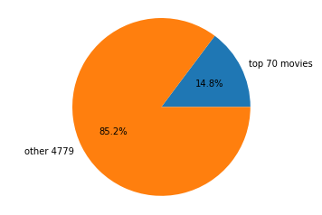

```python
labels = ['top 70 movies', 'other 4779']
sizes = [all_top_movies_adj, (rest_movies_adj - all_top_movies_adj)]

fig1, ax1 = plt.subplots()
ax1.pie(sizes, labels=labels, autopct='%1.1f%%')
ax1.axis('equal')

plt.show()
```

```python
revenue_no_zeros_descending = revenue_no_zeros.sort_values('revenue')

q_1 = revenue_no_zeros_descending.iloc[ : int(len(revenue_no_zeros_descending) * (1/5))]['revenue'].sum()

q_2 = revenue_no_zeros_descending.iloc[int(len(revenue_no_zeros_descending) * (1/5)): int(len(revenue_no_zeros)*(2/5))]['revenue'].sum()

q_3 = revenue_no_zeros_descending.iloc[int(len(revenue_no_zeros_descending) * (2/5)): int(len(revenue_no_zeros_descending) * (3/5))]['revenue'].sum()

q_4 = revenue_no_zeros_descending.iloc[int(len(revenue_no_zeros_descending)*(3/5)): int(len(revenue_no_zeros_descending)*(4/5))]['revenue'].sum()

q_5 = revenue_no_zeros_descending.iloc[int(len(revenue_no_zeros_descending)*(4/5)): ]['revenue'].sum()
```

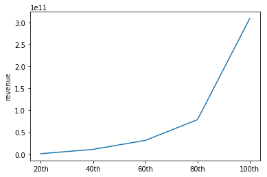

```python
plt.plot(['20th', '40th', '60th', '80th', '100th'], [q_1, q_2, q_3, q_4, q_5])
plt.ylabel('revenue')
plt.show()
```

Price's law doesn't seem to work here by using all movies with info for adjusted revenue. Though we can still see evidence that a small group of movies were disproportiantely productive.

The squre root of all the movies came out to be about 1.4% of all the moves produced. This 1.4% produced about 10 times its representation in the population.

That seems like a lot but not quite up to the 50% levels of Price's law

When quintiles for all the movies are accounted for we can see that the top 20 percent of movies seem to be disproportionately productive compared to the other 80 percent.

```python
unadjusted_revenue_zeros = sorted_revenue[sorted_revenue.revenue != 0]
```

```python
unadjusted_revenue_zeros
```

[output not shown]

4849 rows × 21 columns

```python
len(unadjusted_revenue_zeros)
```

```
4849
```

```python
unadj_total =unadjusted_revenue_zeros['revenue'].sum()
```

```python
unadj_top = unadjusted_revenue_zeros['revenue'].iloc[:69].sum()
```

```python
unadj_top / unadj_total
```

```
0.1415315241292689
```

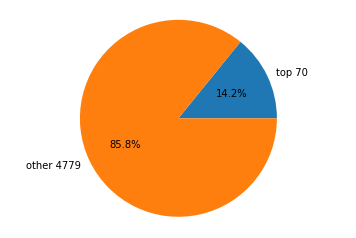

```python
labels_1 = ["top 70", "other 4779"]
sizes_1 = [unadj_top, (unadj_total - unadj_top)]

fig1, ax1 = plt.subplots()
ax1.pie(sizes_1, labels=labels_1, autopct='%1.1f%%')
ax1.axis('equal')

plt.show()
```

Unadjusted revenue appears to give a similar result as adjusted revenue. This makes sense as the adjusted revenues to dollars in 2010 terms would be based off the the original revenues. So if they were unadjusted it makes sense that everything would decline in roughly equal proprtions and give a similar result.

Again we see that about 1.4 percent of the overall population is making up about 10 times its represention in the overall population in reveneue.

There may be holes in the data and its worth checking revenues for a single year where the data might be better.

```python
revenue_by_year = sorted_revenue[sorted_revenue['release_year'] == 2015]
```

```python
len(revenue_by_year)
```

```
629
```

```python
np.sqrt(len(revenue_by_year))
```

```
25.079872407968907
```

```python
price_check = revenue_by_year.iloc[:24]['revenue'].sum()
```

```python
year_revenue = revenue_by_year['revenue'].sum()
```

```python
price_check / year_revenue
```

```
0.6458613213455359
```

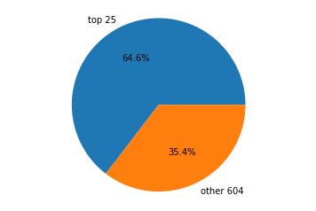

```python
labels = 'top 25', 'other 604'
sizes = [price_check, (year_revenue - price_check)]

fig1, ax1 = plt.subplots()
ax1.pie(sizes, labels=labels, autopct='%1.1f%%')
ax1.axis('equal')

plt.show()
```

```python
revenue_by_year_descending = sorted_revenue.sort_values('revenue')

q_1 = revenue_by_year_descending.iloc[: int((len(revenue_by_year_descending) * (1/5)))]['revenue'].sum()

q_2 = revenue_by_year_descending.iloc[int((len(revenue_by_year_descending) * (1/5))):int((len(revenue_by_year_descending) * (2/5)))]['revenue'].sum()

q_3 = revenue_by_year_descending.iloc[int((len(revenue_by_year_descending)* (2/5))):int((len(revenue_by_year_descending) * (3/5)))]['revenue'].sum()

q_4 = revenue_by_year_descending.iloc[int((len(revenue_by_year_descending) * (3/5))) : int(len(revenue_by_year_descending) * (4/5))]['revenue'].sum()

q_5 = revenue_by_year_descending.iloc[int(len(revenue_by_year_descending) * (4/5)):]['revenue'].sum()
```

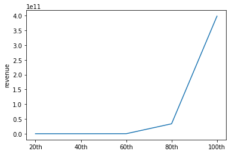

```python
plt.plot(["20th", "40th", "60th", "80th", "100th"], [q_1, q_2, q_3, q_4,q_5])
plt.ylabel('revenue')
plt.show()
```

```python
revenue_by_year_ten = sorted_revenue[sorted_revenue['release_year'] == 2010]
```

```python
length = len(revenue_by_year_ten)

length
```

```
490
```

```python
square = np.sqrt(length)

square
```

```
22.135943621178654
```

```python
square / length
```

```
0.04517539514526256
```

```python
revenue = revenue_by_year_ten.iloc[:21]['revenue'].sum()
```

```python
total = revenue_by_year_ten['revenue'].sum()
```

```python
distribution =revenue / total
```

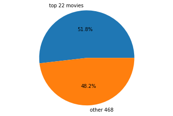

```python
labels = ["top 22 movies", "other 468"]
size = [revenue, (total - revenue)]
explode = (0.1, 0)

fig1, ax1 = plt.subplots()
ax1.pie(size, labels=labels, autopct='%1.1f%%')

ax1.axis('equal')

plt.show()
```

When 2010 is analyized we can see results similar to the year 2015 and we almost get exactly 50% which is what Price's law suggests we should expect.

# Conclusion

Price's law seems to apply to movie revenues if adjusted by year but not when all the movies for all years were taken into account.

It appears that the provided data has issues with all numbers related to revenues not being provided and potentially not being accurate.

Also, it may be more helpful to check this by whether or nor a movie had a theater release as some of the entires in the data appear to have been TV releases. Natually revenue figures for TV realeases will be different and possibly more difficult to collect than Movies release revenues.

While there seem to be issues with the data I think we can conclude that nothing found will prove Price's Law doesn't apply to movie revenues. And we might reasonably epect to see a relatively small group of those movies, whether its the top 20 percent or the top 1 percent, be disproprtionatly productive compared to the rest of the population.